# Simple logistic regression with R

Sara Geremia

2024-05-09

## What is logistic regression?

Suppose a father shares his family’s intention to relocate to a neighborhood in Taiwan, but he face uncertainty about their mortgage approval. However, he possesses information regarding its payment-to-income ratio, which is the ratio of a borrower’s monthly mortgage payment to their monthly income. Consequently, he queries: if he provides the P/I ratio, can you predict whether his mortgage application will be approved or denied?

This inquiry delves into the relationship between a binary mortgage denial variable (the Y variable), where 1 indicates denial and 0 indicates approval, and the P/I ratio (the X variable).

To provide an answer you need to understand how X relates with Y, on average, across various applicants. This knowledge allows the utilization of this relationship to **predict** the likelihood of mortgage denial based on the P/I ratio.

## Simple linear regression model

### Continuous Y

We are interested in the relationship between `mortgage` and `pi_ratio`, a regressor that ought to have power in explaining whether a mortgage application has been denied. It is straight forward to translate this into the simple regression model.

$$\mathbb{E}(mortgage|pi\_ratio) = P(Y =
1|pi\_ratio) =\beta_0 + \beta_{pi\_ratio}\times pi\_ratio$$

With a binary dependent variable it is called the linear probability model. $\beta_1$ can be interpreted as the change in the probability that $Y = 1$,.

It’s important to note that in linear regression, the response variable must be numeric. Hence, if we aim to estimate a linear regression model using `lm()` we’ll have to treat the variable `mortgage` as a numeric variable.

Lets explore our dataset.

```r
# library(AER)
# data(HMDA)

# Set seed for reproducibility
set.seed(123)

# Number of observations
n <- 414

# Generate P/I ratio values (assuming a normal distribution)
pi_ratio <- rnorm(n, mean = 0.4, sd = 0.1)

# Generate mortgage variable based on P/I ratio
mortgage_prob <- pnorm(pi_ratio, mean = 0.4, sd = 0.1)
mortgage <- rbinom(n, size = 1, prob = mortgage_prob)

# Create dataset
mortgage_data <- data.frame(mortgage = mortgage, pi_ratio = pi_ratio)

# Display the first few rows of the dataset
head(mortgage_data)
```

```
##   mortgage  pi_ratio
## 1        0 0.3439524
## 2        1 0.3769823
## 3        1 0.5558708
## 4        0 0.4070508
## 5        1 0.4129288
## 6        1 0.5715065
```

```r
summary(mortgage_data)
```

```
##     mortgage         pi_ratio
##  Min.   :0.0000   Min.   :0.1534
##  1st Qu.:0.0000   1st Qu.:0.3399
##  Median :0.0000   Median :0.3966
##  Mean   :0.4855   Mean   :0.4013
##  3rd Qu.:1.0000   3rd Qu.:0.4649
##  Max.   :1.0000   Max.   :0.7241
```

Before you can run any statistical models, it’s usually a good idea to visualize your dataset and perform summary statistics.

```r
mortgage_data %>%
  summarise_all(mean)
```

```
##    mortgage  pi_ratio
## 1 0.4855072 0.4012585
```

```r
mortgage_data %>%
  summarise(correlation = cor(mortgage, pi_ratio))
```

```
##   correlation
## 1   0.6027167
```

To visualize the relationship between two numeric variables, you can use a scatter plot. In the plot, you can see that the percentage of application denial seem to increase as the P/I ratio increases. It would be nice to be able to describe this increase more precisely.

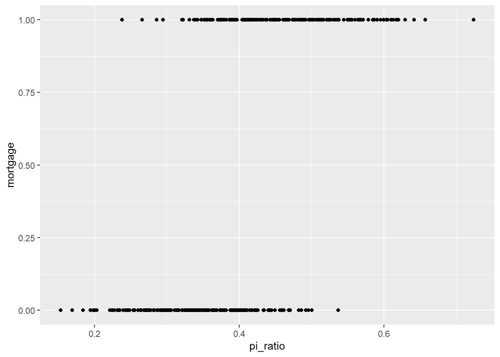

```r
ggplot(
  data = mortgage_data,
  mapping = aes(x = pi_ratio, y = mortgage)) +
  geom_point()
```

One refinement we can make is to add a trend line to the scatter plot. A trend line means fitting a line that follows the data points. In ggplot, trend lines are added using geom_smooth(). Setting the method argument to “lm”, for “linear model” gives a trend line calculated with a linear regression. This means the trend line is a straight line that follows the data as closely as possible.

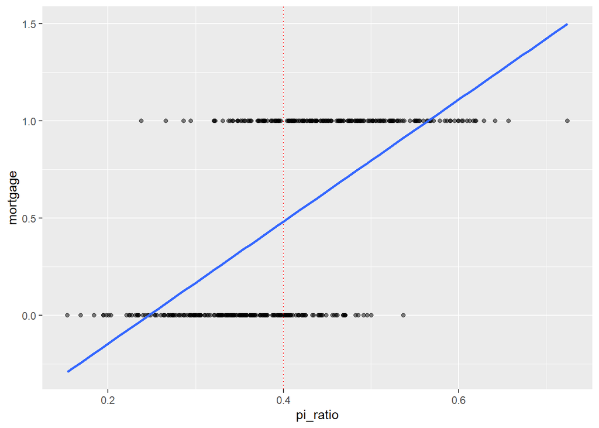

```r
ggplot(
  mortgage_data,
  aes(pi_ratio, mortgage)) +
  geom_point(alpha = .5) +
  geom_vline(xintercept = 0.4, color = "red", linetype = "dotted") +
  geom_smooth(
    method = "lm",
    se = FALSE)
```

According to the estimated trend line, a P/I ratio of 0.4 is associated with an expected probability of mortgage application denial of roughly 50%. The plot indicates that there is a positive relation between the P/I ratio and the probability of a denied mortgage application so individuals with a high ratio of loan payments to income are more likely to be rejected.

**Let’s run a linear regression to estimate the coefficients of the model.**

To run a linear regression model, you call the `lm` function.

```r
mdl_mort_vs_pi <- lm(mortgage ~ pi_ratio, data = mortgage_data)
summary(mdl_mort_vs_pi)
```

```
##
## Call:
## lm(formula = mortgage ~ pi_ratio, data = mortgage_data)
##
## Residuals:
##      Min       1Q   Median       3Q      Max
## -0.91106 -0.32757 -0.03538  0.32638  1.02617
##
## Coefficients:
##             Estimate Std. Error t value Pr(>|t|)
## (Intercept) -0.77373    0.08445  -9.162   <2e-16 ***
## pi_ratio     3.13823    0.20469  15.331   <2e-16 ***
## ---
## Signif. codes:  0 '***' 0.001 '**' 0.01 '*' 0.05 '.' 0.1 ' ' 1
##
## Residual standard error: 0.3998 on 412 degrees of freedom
## Multiple R-squared:  0.3633, Adjusted R-squared:  0.3617
## F-statistic: 235.1 on 1 and 412 DF,  p-value: < 2.2e-16
```

# Probit and Logit Regression

The linear probability model has a major flaw: it assumes the the conditional probability function

$$\mathbb{E}(Y|X) = P(Y = 1|X) = \beta_0 +
\beta_1 X$$
to be linear. This does not restict $P(Y = 1|X)$ to lie between 0 and 1. Indeed, from our application we noted that with a P/I ratio close to 0, the predicted probability of denial is negative so the model has **no meaningful interpretation**.

This issue calls for an approach that uses a nonlinear function to model the conditional probability function of our binary variable. Commonly used methods are Probit and Logit regression.

## Probit Regression

In **Probit regression**, the cumulative standard normal distribution function $\Phi(\cdot)$ is used to model the regression function:

$$P(Y = 1|X) = \Phi(\beta_0 + \beta_1
X)$$

$\beta_0 + \beta_1 X$ plays the role of a quantile $z$.

$$\Phi(z) = P(Z < x),\,\, Z \sim
\mathcal{N}(0, 1)$$

such that the coefficient $\beta_1$ is the change in $z$ associated with a one unit change in X. While the link between $z$ and Y is non linear, since $\Phi$ is a non linear function.

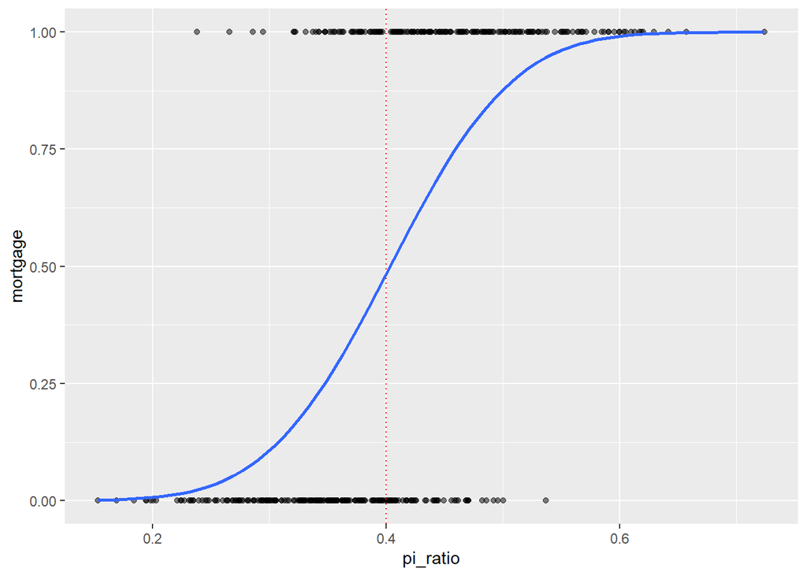

```r
ggplot(
  data = mortgage_data,
  aes(pi_ratio, mortgage)) +
  geom_point(alpha = .5) +
  geom_vline(xintercept = .4, color = "red", linetype = "dotted") +
  geom_smooth(
    method = "glm", method.args=list(family=binomial(link="probit")),
    se = FALSE)
```

The estimated regression function has a streched “S”-shape, it is cleary nonlinear and flattens out for large and small values of P/I ratio. The functional form also ensures that the predicted conditional probabilities of a denial lie between 0 and 1.

Another helpful visualization to explore the relationship between the two variables consist in the boxplot

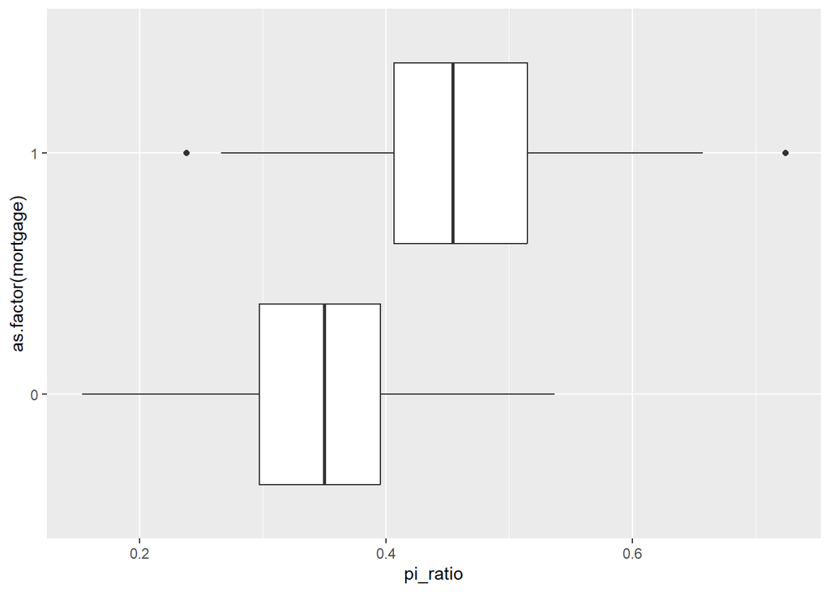

```r
ggplot(
  mortgage_data,
  aes(pi_ratio, as.factor(mortgage))) +
  geom_boxplot()
```

Probit models can be estimated using the function `glm()`. Using the argument `family` we specify that we want to use a Probit link function.

```r
# estimate the simple probit model

mdl_probit <- glm(mortgage ~ pi_ratio,
                  data = mortgage_data,
                  family = binomial(link = "probit"))
summary(mdl_probit)
```

```
##
## Call:
## glm(formula = mortgage ~ pi_ratio, family = binomial(link = "probit"),
##     data = mortgage_data)
##
## Coefficients:
##             Estimate Std. Error z value Pr(>|z|)
## (Intercept)  -4.8511     0.4461  -10.87   <2e-16 ***
## pi_ratio     12.0260     1.1027   10.91   <2e-16 ***
## ---
## Signif. codes:  0 '***' 0.001 '**' 0.01 '*' 0.05 '.' 0.1 ' ' 1
##
## (Dispersion parameter for binomial family taken to be 1)
##
##     Null deviance: 573.58  on 413  degrees of freedom
## Residual deviance: 384.72  on 412  degrees of freedom
## AIC: 388.72
##
## Number of Fisher Scoring iterations: 5
```

Just as in the linear probability model we find that the relation between the probability of denial and the P/I ratio is positive and that the corresponding coefficient is highly significant.

$\beta_1$ does not have a simple interpretation. An idea is to calculate the estimated effect on Y associated with a change in X, for one or more values of X.

We use `predict()` to compute the predicted change in the denial probability when P/I ratio is increased from 0.4 to 0.5.

```r
predictions <- predict(mdl_probit,
  newdata = data.frame("pi_ratio" = c(0.4, 0.5)), type = "response"
)

diff(predictions)
```

```
##         2
## 0.3935921
```

We find that an increase in P/I ratio from 0.4 to 0.5 is predicted to increase the probability of denial by approximately 39.4%.

## Logit Regression

In **Logit regression**, the standard cumulative logistic distribution function $F(x) = \frac{1}{1 + e^{-x}}$ is used to model the regression function:

$$P(Y = 1|X) = F(\beta_0 + \beta_1
X)=\frac{1}{1+ e^{-(\beta_0 + \beta_1 X)}}$$

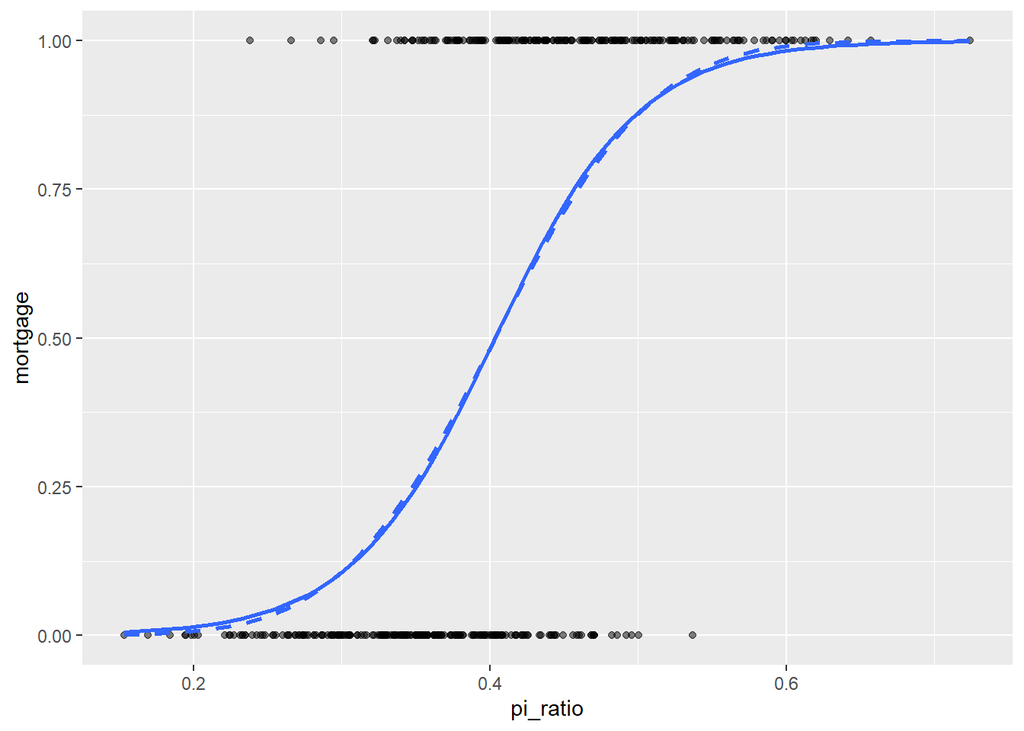

```r
ggplot(
  mortgage_data,
  aes(pi_ratio, mortgage)) +
  geom_point(alpha = .5) +
  geom_smooth(
    method = "glm", method.args=list(family=binomial(link = "logit")),
    se = FALSE) +
  geom_smooth(
    method = "glm", method.args=list(family=binomial(link = "probit")),
    se = FALSE, linetype = 2)
```

The estimated regression functions has a very similar stretched “S”-shape.

Logit models can be estimated using the function `glm()`. Using the argument `family` we specify that we want to use a Logit link function.

```r
# estimate the simple logit model

mdl_logit <- glm(mortgage ~ pi_ratio,
                  data = mortgage_data,
                  family = binomial(link = "logit"))
summary(mdl_logit)
```

```
##
## Call:
## glm(formula = mortgage ~ pi_ratio, family = binomial(link = "logit"),
##     data = mortgage_data)
##
## Coefficients:
##             Estimate Std. Error z value Pr(>|z|)
## (Intercept)  -8.3191     0.8407  -9.896   <2e-16 ***
## pi_ratio     20.6201     2.0808   9.910   <2e-16 ***
## ---
## Signif. codes:  0 '***' 0.001 '**' 0.01 '*' 0.05 '.' 0.1 ' ' 1
##
## (Dispersion parameter for binomial family taken to be 1)
##
##     Null deviance: 573.58  on 413  degrees of freedom
## Residual deviance: 385.09  on 412  degrees of freedom
## AIC: 389.09
##
## Number of Fisher Scoring iterations: 5
```

Both models produce very similar estimates of the probability that a mortgage application will be denied depending on the applicants P/I ratio.

$\beta_1$ does not have a simple interpretation. Let’s calculate the estimated effect on Y associated with a change in X, for one or more values of X.

We use `predict()` to compute the predicted change in the denial probability when P/I ratio is increased from 0.4 to 0.5.

```r
predictions <- predict(mdl_logit,
  newdata = data.frame("pi_ratio" = c(0.4, 0.5)), type = "response"
)

diff(predictions)
```

```
##         2
## 0.3976007
```

We find that an increase in P/I ratio from 0.4 to 0.5 is predicted to increase the probability of denial by approximately 39.8%.

A commonly used approch to interpret the coefficients of a logistic regression model is to define the logit function

$$logit(P(Y = 1|X)) = log(\frac{P(Y =
1|X)}{1-P(Y = 1|X)}) = \beta_0 + \beta_1 X$$

The logit (i.e., the logarithm of the odds) is equivalent to the linear regression expression.

$$odds = \frac{P(Y = 1|X)}{1-P(Y = 1|X)} =
e^{\beta_0 + \beta_1 X}$$

For a continuous independent variable the odds ratio can be defined as:

$$OR = \frac{odds(Y|X + 1)}{odds(Y|X)} =
\frac{e^{\beta_0 + \beta_1 (X+1)}}{e^{\beta_0 + \beta_1 X}} =
e^{\beta_1}$$

This exponential relationship provides an interpretation for $\beta_1$: The odds multiply by $e^{\beta_1}$ for every 1-unit increase in X.

If you want to interpret the effect of a smaller change in the predictor variable (e.g., a 0.01 unit increase in X) on the odds of the outcome, you can adjust the coefficient accordingly.

In logistic regression, the interpretation of the coefficient remains the same, but you scale it based on the desired increment in the predictor variable.

Here’s how you can interpret the effect of a 0.01 unit increase in X:

1. Obtain the odds ratio associated with a one-unit increase in X by exponentiating the coefficient $\beta_1$.
2. Raise the odds ratio to the power of 0.01 to account for the smaller increment.

Mathematically, the adjusted odds ratio for a 0.01 unit increase in X is:

$$e^{\beta_1 \times 0.01}$$

In our example:

```r
exp(mdl_logit$coefficients[2] * 0.01)
```

```
## pi_ratio
##    1.229
```

### Binary X

```r
library(AER)
data(HMDA)

?HMDA
```

```r
#table(HMDA$deny, ...)
```

Binary variables can either be treated as numerical, usually dummy 0/1 variables, or as factors. It does not make any difference in terms of the results obtained from the model but we have to be aware of how they are coded for a correct interpretation of the model.

In general, the model will always have 1 parameter for a binary variable. However, we have to choose which level the parameter should represent by deciding which group to code with 1. The choice should be made according to how we want the model to be interpreted. For example, for the treatment variable, 0 is usually the placebo or the control treatment and 1 is usually the experimental treatment. Alternatively, in the case of the explanatory variables, we could simply use a statistical criteria: for a better stability of the model it is always better to use the most frequent category as a reference.

```r
HMDA$deny01 <- ifelse(HMDA$deny == "yes", 1, 0)
```

The odds is:
$$\text{Odds}(Y|X) =
\frac{P(Y|X)}{1 - P(Y|X)} = \frac{\frac{e^{\beta_0 + \beta_1 X}}{1 +
e^{\beta_0 + \beta_1 X}}}{\frac{1}{1 + e^{\beta_0 + \beta_1 X}}}
= e^{\beta_0 + \beta_1 X}$$

$$Odds(Y|X = 1) = \exp^{\beta_0 +
\beta_1}, \,\,\,\,\,\,\,\,\,\,\,\,\,\,\,\,\,\,\,\,Odds(Y|X = 0) =
\exp^{\beta_0}$$

$$OR = \frac{Odds(Y|X = 1)}{Odds(Y|X =
0)}=\frac{\exp^{\beta_0 +
\beta_1}}{\exp^{\beta_0}}=\exp^{\beta_1}$$

$$ln(OR) = \beta_1$$

### Categorical X with K levels

Before starting to fit any regression model we have to properly code categorical variables. This is usually done in the initial data analysis and the descriptive statistics phase.

The first step consists in identifying which variables are categorical. This may seem as an easy step but it isn’t always. If fact the choice for some variables (i.e. indexes and scales) is not obvious and it requires either knowledge of the data we are analysing or a bit more effort on the data modelling.

We must transform the variable into a factor, assign labels to the factor levels and choose a reference level. The reference level will be the group all the others levels will be compared to. In fact when a factor variable with K levels is added to a model, R internally transforms it in K-1 dummy variables and a model parameter will be estimated for each of them. Again, is important we choose the reference level. In this case we have `unemp` which we have to transform into a factor

```r
summary(HMDA$unemp)
```

```
##    Min. 1st Qu.  Median    Mean 3rd Qu.    Max.
##   1.800   3.100   3.200   3.774   3.900  10.600
```

```r
HMDA_Q <- round(quantile(HMDA$unemp, probs = c(0.33, .66)), 2)

HMDA$unemp_cat <- as.factor(ifelse(HMDA$unemp < HMDA_Q[1], paste("<", HMDA_Q[1]),
                     ifelse(HMDA$unemp > HMDA_Q[2], paste(">", HMDA_Q[2]),
                                                           paste(HMDA_Q[1],"-", HMDA_Q[2]))))
```

We can now check how R has coded the variable:

```r
str(HMDA$unemp_cat)
```

```
##  Factor w/ 3 levels "< 3.2","> 3.6",..: 2 3 3 2 3 2 2 1 1 2 ...
```

```r
contrasts(HMDA$unemp_cat)
```

```
##           > 3.6 3.2 - 3.6
## < 3.2         0         0
## > 3.6         1         0
## 3.2 - 3.6     0         1
```

|  | D1 | D2 |
| --- | --- | --- |
| $< 3.2$ | 0 | 0 |
| $> 3.6$ | 1 | 0 |
| $3.2-3.6$ | 0 | 1 |

By default, R uses the group 1 as the reference level. With the `contrasts()` function we can see how the variable will be parametrized in the regression model. In the rows we have the variable levels and on the columns the parameters generated for this variable.

$\text{Odds}(Y|X = < 3.2) = e^{\beta_0 + \beta_1 (D1 = 0) + \beta_2 (D2 = 0)}$

Last but not least we can set the reference category of our choice. In this case we choose “3.2 - 3.6” which is the most frequent category.

```r
table(HMDA$unemp_cat)
```

```
##
##     < 3.2     > 3.6 3.2 - 3.6
##       640       689      1051
```

```r
HMDA$unemp_cat <- relevel(HMDA$unemp_cat, ref="3.2 - 3.6")

contrasts(HMDA$unemp_cat)
```

```
##           < 3.2 > 3.6
## 3.2 - 3.6     0     0
## < 3.2         1     0
## > 3.6         0     1
```

If the variable is of type character the steps are similar to the previous ones with the exception that we won’t need to explicitly set the labels. As a reminder, by default R uses as a reference level the first level in alphabetical order.